# Outwit, Outplay, Outpredict: Spotting the Front-Runner by Episode Three

Author

Elisabeth Gangwer

## Introduction

Survivor seems to be an unpredictable show, with countless twists and a wide range of people from a variety of different backgrounds. Survivor has always been a show my family would watch together. And one of my favorite moments when I watched the show was guessing who was going to win or who was getting voted out. I have always wanted to know if there were any indicators in the early parts of a season that point to any front runners or the actual winner.  
For my final project, I will be looking at a data set that provides many data tables regarding information on all of the seasons and versions of survivor, episode summary, players(*castaways*), confessionals, and voting history. I will compare these findings to the latest season of Survivor.

### Primary Questions

My primary questions is: Are there elements in the first three episodes of a season that point to a front runner for winning the season? Based on these elements, who is(are) the front runner(s) for season 47?

1. What is the relationship between *x* and *y*?
1. *x* is the winners/front runners of the specified season.  
   *y* is episode elements like the total amount of confessionals, voting accuracy, challenge wins, etc.
2. Is there a group difference between *x* on *y*? Do the winners/front runners have more confessionals in the first three episodes compared to the non-winning players?

## Data

The data that I am using for this project can be accessed from [github/doehm/survivoR](https://github.com/doehm/survivoR) The data I used from github was separated into multiple *.rda* files with information from all versions of survivor with every season, castaway, confessional, etc… Essentially, there is a lot of data.  
Before starting, I cleaned & extracted most of the data I would need in a separate r document.  
Loading cleaned & extracted data.

```r
library(dplyr)
library(reshape2)
library(ggplot2)
load("finalproject_dataframes.RData")
rmarkdown::paged_table(winner_df)
```

**Changes**  
After adding my extracted data, I realized there were a few more things I wanted to add and change to the dataframes.  
I created a new data frame of all players and added a TRUE or FALSE if they are the winner or not of that season. This data frame provides information on the first three episodes of a season and if the castaway is the winner or not. US Versions Seasons 1 - 46 are being used.

```r
castaway_df <- confessionals_df_wide
colnames(castaway_df)[4] = "ep1_confessional"
colnames(castaway_df)[5] = "ep2_confessional"
colnames(castaway_df)[6] = "ep3_confessional"
colnames(castaway_df)[7] = "total_confessional"
castaway_df <- merge(castaway_df,
                     winner_df,
                     by = "castaway_id",
                     all.x = TRUE)
castaway_df$winner <- ifelse(castaway_df$season.x == castaway_df$season.y, TRUE, FALSE)
castaway_df <- castaway_df[, c(1:7,9)]
colnames(castaway_df)[2] = "season"
colnames(castaway_df)[3] = "castaway"
castaway_df$winner[is.na(castaway_df$winner)] <- FALSE
```

**Potential Issues**  
I noticed that there were some issues with the castaway_df, winners (*Sandra and Tony*) that had played multiple times and won the game more than once were being repeated for all of the seasons they played and were returning both TRUE and FALSE. Using the duplicated function, I found the specific rows that were returning these errors. Then, I looked into what season’s the two-time winners had won and removed the inaccurate rows.

```r
castaway_df <- castaway_df[order(castaway_df$season),]
sandra <- castaway_df %>%
  filter(castaway_id == "US0112")
duplicates_specific <- castaway_df[duplicated(castaway_df[c("castaway_id", "season")]) |
                                        duplicated(castaway_df[c("castaway_id", "season")], fromLast = TRUE), ]
castaway_df <- castaway_df[c(-151, -148, -548, -152, -543, -154, -545),]
castaway_df$winner <- ifelse(castaway_df$winner == "TRUE", "WINNER", "LOSER")
rmarkdown::paged_table(castaway_df)
```

|  | castaway_id | season | castaway | ep1_confessional | ep2_confessional | ep3_confessional | total_confessional | winner |
| --- | --- | --- | --- | --- | --- | --- | --- | --- |
| 1 | US0001 | 1 | Sonja | 2 | NA | NA | 2 | LOSER |
| 2 | US0002 | 1 | B.B. | 3 | 8 | NA | 11 | LOSER |
| 3 | US0003 | 1 | Stacey | 1 | 2 | 6 | 9 | LOSER |
| 4 | US0004 | 1 | Ramona | 2 | 9 | 0 | 11 | LOSER |
| 5 | US0005 | 1 | Dirk | 1 | 0 | 3 | 4 | LOSER |
| 6 | US0006 | 1 | Joel | 2 | 2 | 2 | 6 | LOSER |
| 7 | US0007 | 1 | Gretchen | 1 | 6 | 3 | 10 | LOSER |
| 8 | US0008 | 1 | Greg | 0 | 4 | 4 | 8 | LOSER |
| 9 | US0009 | 1 | Jenna | 0 | 2 | 4 | 6 | LOSER |
| 11 | US0010 | 1 | Gervase | 0 | 6 | 5 | 11 | LOSER |

[output cut: 847 more lines]

**Adding the Eras**  
I also wanted to add the eras of Survivor defined here by [Vulture](https://www.vulture.com/article/survivor-guide-best-eras-seasons-players-moments.html). To better visualize and separate the data later on.

```r
season_era <- data.frame(1:47)
season_era$season <- seq(1:47)
season_era$era <- seq(1:47)
season_era$era[1:8] <- "The Golden Age"
season_era$era[9:14] <- "The Identity Crisis"
season_era$era[15:20] <- "The Renaissance"
season_era$era[21:26] <- "The Dark Ages"
season_era$era[27:32] <- "The Re-Renaissance"
season_era$era[33:40] <- "The Worst Themes"
season_era$era[41:47] <- "The New Era"

castaway_df <- inner_join(castaway_df, season_era)
castaway_df <- castaway_df[, -9]
```

**Losers/Non-Winner Table** I decided to create a losers/non-winners data frame because I already had a dataframe containing information on the winners.

```r
loser_df <- castaway_df[castaway_df$winner == "LOSER",]
```

**Smaller Sample** Bring “The New Era” players into a new data frame to create a smaller sample size.

```r
new_era_castaways <- castaway_df[castaway_df$era == "The New Era", ]
new_era_winners <- new_era_castaways[new_era_castaways$winner == "WINNER", ]
new_era_losers <- new_era_castaways[new_era_castaways$winner == "LOSER", ]
```

**Calculating Averages** I then created multiple data frames that contains the average number of confessionals per player in the first three episodes of a season. I used the dplyr package to group the players by season and winners/non-winners  
(*number of confessionals / total players left in the game*)

```r
firstEp_avg <- castaway_df %>%
  group_by(season, winner) %>%
  summarise(ep1_total = sum(ep1_confessional), count = n(), ep1_avg = mean(ep1_confessional)) %>%
  arrange(season)
firstEp_avg <- firstEp_avg[-93, ]

ep2_avg <- castaway_df %>%
  filter(!is.na(ep2_confessional)) %>%
  group_by(season, winner) %>%
  summarise(sum = sum(ep2_confessional),
            count = n(), avg = mean(ep2_confessional)) %>%
  arrange(season)
ep3_avg <- castaway_df %>%
  filter(!is.na(ep3_confessional)) %>%
  group_by(season, winner) %>%
  summarise(sum = sum(ep3_confessional),
            count = n(), avg = mean(ep3_confessional)) %>%
  arrange(season)
firstEp_avg <- firstEp_avg[-93, ]
ep2_avg <- ep2_avg[-93, ]

total_avg <- firstEp_avg
total_avg$ep2_avg <- ep2_avg$avg
total_avg$ep3_avg <- ep3_avg$avg
total_avg <- total_avg[, c(-3, -4)]
total_avg$total <- (total_avg$ep1_avg + total_avg$ep2_avg + total_avg$ep3_avg)/3
```

**Season 47** Load & Update Season 47 Data for the first three episodes

```r
load("~/Desktop/DataWrangling/final_project/data/confessionalsCopy.rda")
confessional_47 <- confessionals
confessional_47 <- confessional_47[confessional_47$version_season == "US47",]
confessional_47 <- confessional_47[, 4:8]
```

Make the season 47 data frame wider for clarity purposes & calculate the average three episode confessional count of said player

```r
confessional_47 <- dcast(confessional_47,
                        formula = season + castaway + castaway_id ~ episode,
                        value.var = "confessional_count")
colnames(confessional_47)[4] = "ep1_confessional"
colnames(confessional_47)[5] = "ep2_confessional"
colnames(confessional_47)[6] = "ep3_confessional"
confessional_47$total <- confessional_47$ep1_confessional +
  confessional_47$ep2_confessional +
  confessional_47$ep3_confessional
confessional_47$total_avg <- confessional_47$total / 3
```

**Voting accuracy for season 47.**

```r
load("~/Desktop/DataWrangling/final_project/data/vote_historyCopy.rda")
vote_47 <- vote_history[vote_history$version_season == "US47",]
vote_47 <- vote_47[,c(4,5,9,20,11,17,21,22)]
vote_47$correctly_voted <- ifelse(vote_47$vote_id == vote_47$voted_out_id, TRUE, FALSE)
vote_47$voting_accuracy <- ifelse(vote_47$correctly_voted == TRUE, 1.00, 0.00)
vote_47 <- dcast(vote_47,
                  formula = season + castaway_id + castaway + voting_accuracy ~ episode,
                  value.var = "correctly_voted")
colnames(vote_47)[5] = "ep1_correctly_voted"
colnames(vote_47)[6] = "ep2_correctly_voted"
colnames(vote_47)[7] = "ep3_correctly_voted"
```

## Methods

**t-test** I decided to conduct a t-test of the confessional count of winners & losers from all seasons to determine if the average number of confessionals a player has a relationship with winning players.  
*Null Hypothesis:* The total confessional count of winner’s is equal to the total confessional count of the losers.  
*Alternative Hypothesis:* The total confessional count of winner’s is different from the total confessional count of the losers.

```r
t.test(winner_df$Total_Confessional_Count, loser_df$total_confessional)
```

```
    Welch Two Sample t-test

data:  winner_df$Total_Confessional_Count and loser_df$total_confessional
t = 1.3663, df = 49.488, p-value = 0.178
alternative hypothesis: true difference in means is not equal to 0
95 percent confidence interval:
 -0.4652406  2.4430458
sample estimates:
mean of x mean of y
 8.000000  7.011097
```

I decided to conduct a t-test of the confessional count of winners & losers of the new era to create a smaller sample size.  
Null Hypothesis: The total confessional count of winner’s is equal to the total confessional count of the new era losers.  
Alternative Hypothesis: The total confessional count of winner’s is different from the total confessional count of the new era winners.

```r
t.test(new_era_losers$total_confessional, new_era_winners$total_confessional)
```

```
    Welch Two Sample t-test

data:  new_era_losers$total_confessional and new_era_winners$total_confessional
t = -1.1662, df = 5.3802, p-value = 0.2926
alternative hypothesis: true difference in means is not equal to 0
95 percent confidence interval:
 -9.158813  3.358813
sample estimates:
mean of x mean of y
 8.933333 11.833333
```

T-test of first episode confessional count for the new era and all seasons.

```r
t.test(winner_df$Ep1_Confessional_Count, loser_df$ep1_confessional)
```

```
    Welch Two Sample t-test

data:  winner_df$Ep1_Confessional_Count and loser_df$ep1_confessional
t = 0.28713, df = 50.462, p-value = 0.7752
alternative hypothesis: true difference in means is not equal to 0
95 percent confidence interval:
 -0.6416877  0.8558087
sample estimates:
mean of x mean of y
 3.304348  3.197287
```

```r
t.test(new_era_losers$ep1_confessional, new_era_winners$ep1_confessional)
```

```
    Welch Two Sample t-test

data:  new_era_losers$ep1_confessional and new_era_winners$ep1_confessional
t = -0.23739, df = 5.6372, p-value = 0.8207
alternative hypothesis: true difference in means is not equal to 0
95 percent confidence interval:
 -2.867666  2.367666
sample estimates:
mean of x mean of y
 4.416667  4.666667
```

*Fail to reject the null hypothesis.*  
**New Approach** After completing the t-test and failing to reject the null hypothesis, I decided to find the average confessional count of the new era’s first episode and first three episodes. This will help determine the possible front runner’s of Season 47.

```r
loser_total_df <- total_avg[total_avg$winner=="LOSER",]
loser_total_df_new_era <- loser_total_df[loser_total_df$season > 41, ]
new_era_loser_mean <- mean(loser_total_df_new_era$ep1_avg)
new_era_loser_total_mean <- mean(loser_total_df_new_era$total)
```

*Loser Average Confessionals for first three episodes: 3.242*  
*Loser Average Confessionals for first episode: 4.37*  
Look at Season 47 players who’s total confessional count average is above The New Era non-winner confessional average.  
*Filter Season 47 players who’s first confessional count is above 4.40.*

```r
above_average <- confessional_47
above_average <- above_average[above_average$total_avg >= 3.24, ]
above_average <- na.omit(above_average)
above_average <- above_average[above_average$ep1_confessional > 4.4, ]
really_above_average <- inner_join(above_average, vote_47)
rmarkdown::paged_table(really_above_average)
```

| season | castaway | castaway_id | ep1_confessional | ep2_confessional | ep3_confessional | total | total_avg | voting_accuracy | ep1_correctly_voted | ep2_correctly_voted | ep3_correctly_voted |
| --- | --- | --- | --- | --- | --- | --- | --- | --- | --- | --- | --- |
| 47 | Andy | US0698 | 7 | 6 | 3 | 16 | 5.333333 | 1 | TRUE | NA | NA |
| 47 | Aysha | US0700 | 13 | 1 | 6 | 20 | 6.666667 | 0 | NA | NA | FALSE |
| 47 | Gabe | US0702 | 11 | 7 | 3 | 21 | 7.000000 | 1 | NA | TRUE | NA |
| 47 | Rachel | US0707 | 7 | 1 | 3 | 11 | 3.666667 | 1 | TRUE | NA | NA |
| 47 | Rome | US0708 | 9 | 3 | 9 | 21 | 7.000000 | 1 | NA | NA | TRUE |

## Results & Discussion

**Some visualizations:**

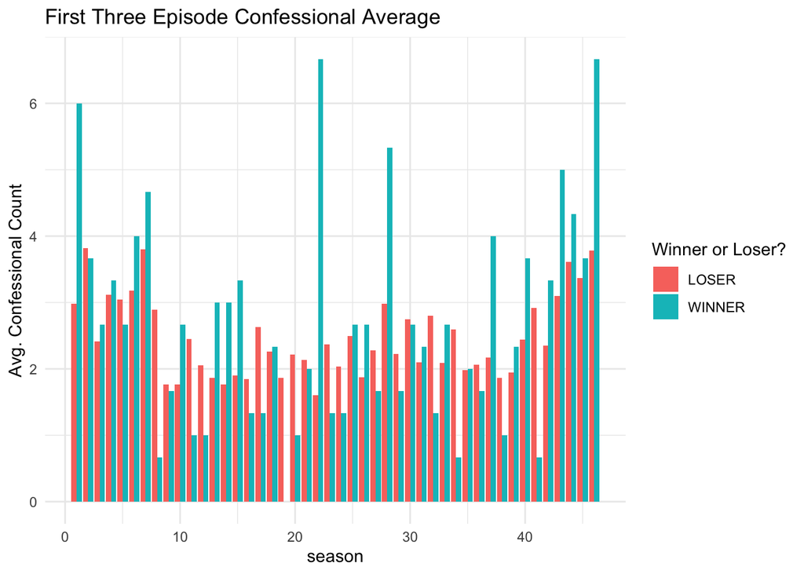

```r
ggplot(total_avg, aes(x = season, y = total, fill = winner)) +
  geom_col(position ='dodge') +
  labs(title = 'First Three Episode Confessional Average', fill = 'Winner or Loser?',
       y = 'Avg. Confessional Count') +
  theme_minimal()
```

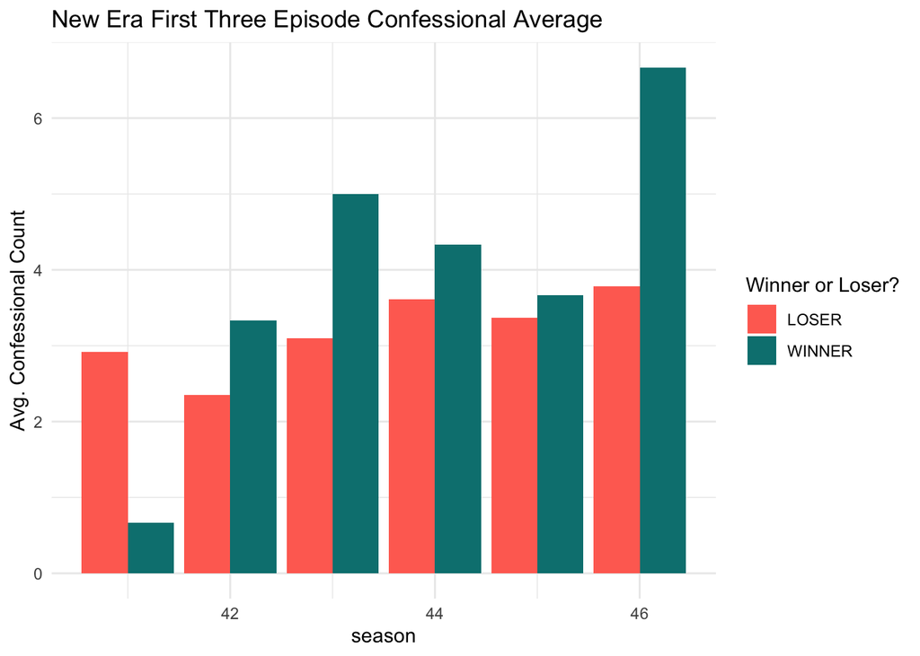

```r
new_era_total <- total_avg[total_avg$season > 40, ]
ggplot(new_era_total, aes(season, total, fill = winner)) +
  geom_col(position = 'dodge') +
  scale_fill_manual(values = c("WINNER" = "#008080", "LOSER" = "#FF6F61")) +
  labs(title = 'New Era First Three Episode Confessional Average', fill = 'Winner or Loser?',
       y = 'Avg. Confessional Count') +
  theme_minimal()
```

Looking at most recent season *(Season 46)* episode confessional count

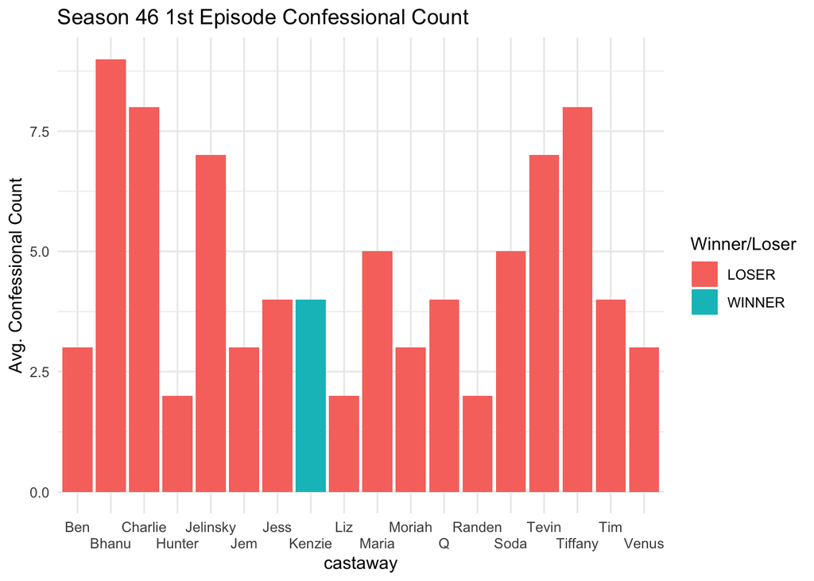

```r
season_46 <- castaway_df[castaway_df$season == '46', ]
ggplot(season_46,aes(castaway, ep1_confessional, fill = winner)) +
  geom_col(position = position_dodge(width = 5)) +
   labs(title = 'Season 46 1st Episode Confessional Count', fill = 'Winner/Loser',
       y = 'Avg. Confessional Count') +
  scale_x_discrete(guide = guide_axis(n.dodge=2)) +
  theme_minimal()
```

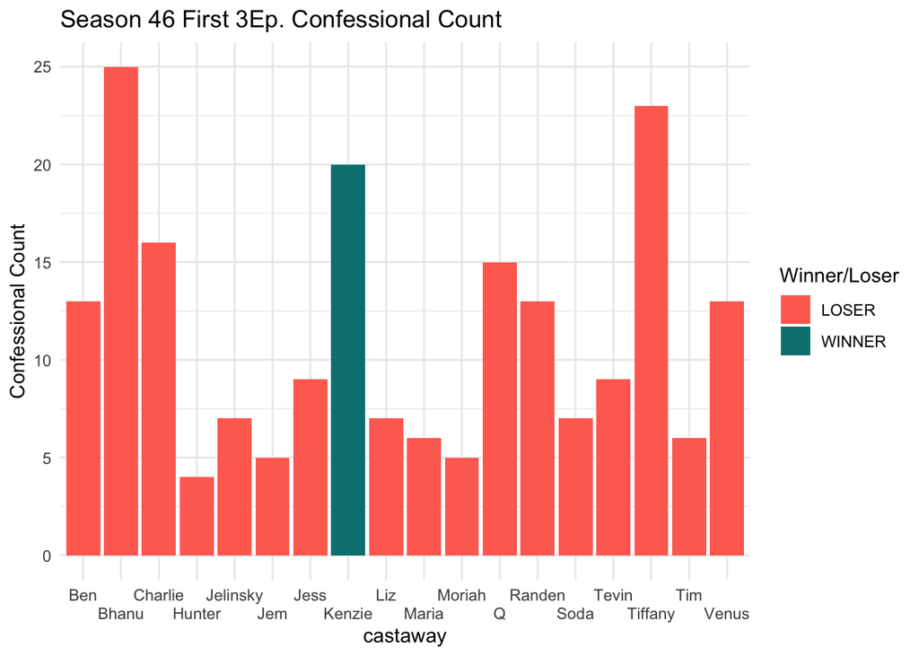

```r
ggplot(season_46,aes(castaway, total_confessional, fill = winner)) +
  geom_col(position = position_dodge(width = 5)) +
  scale_fill_manual(values = c("WINNER" = "#008080", "LOSER" = "#FF6F61")) +
   labs(title = 'Season 46 First 3Ep. Confessional Count', fill = 'Winner/Loser',
       y = 'Confessional Count') +
  scale_x_discrete(guide = guide_axis(n.dodge=2)) +
  theme_minimal()
```

**Season 47 Front Runners**

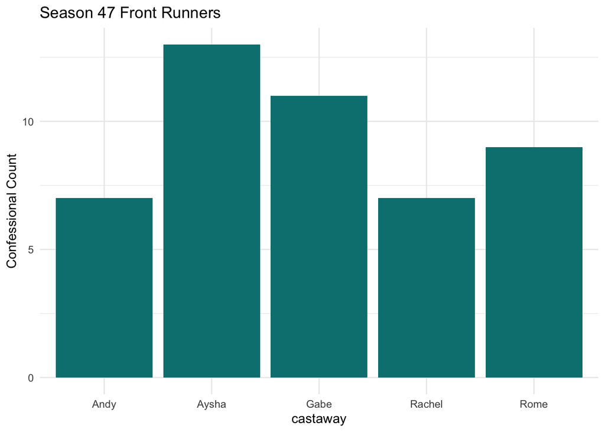

```r
ggplot(really_above_average, aes(castaway, ep1_confessional)) +
  geom_col(width = 0.9, fill = "#008080") +
  labs(title = 'Season 47 Front Runners', y = 'Confessional Count') +
  theme_minimal() +
  theme(legend.position = "none")
```

```r
rmarkdown::paged_table(castaway_df)
```

| castaway_id | season | castaway | ep1_confessional | ep2_confessional | ep3_confessional | total_confessional | winner | era |
| --- | --- | --- | --- | --- | --- | --- | --- | --- |
| US0001 | 1 | Sonja | 2 | NA | NA | 2 | LOSER | The Golden Age |
| US0002 | 1 | B.B. | 3 | 8 | NA | 11 | LOSER | The Golden Age |
| US0003 | 1 | Stacey | 1 | 2 | 6 | 9 | LOSER | The Golden Age |
| US0004 | 1 | Ramona | 2 | 9 | 0 | 11 | LOSER | The Golden Age |
| US0005 | 1 | Dirk | 1 | 0 | 3 | 4 | LOSER | The Golden Age |
| US0006 | 1 | Joel | 2 | 2 | 2 | 6 | LOSER | The Golden Age |
| US0007 | 1 | Gretchen | 1 | 6 | 3 | 10 | LOSER | The Golden Age |
| US0008 | 1 | Greg | 0 | 4 | 4 | 8 | LOSER | The Golden Age |
| US0009 | 1 | Jenna | 0 | 2 | 4 | 6 | LOSER | The Golden Age |
| US0010 | 1 | Gervase | 0 | 6 | 5 | 11 | LOSER | The Golden Age |

[output cut: 847 more lines]

```r
rmarkdown::paged_table(winner_df)
```

| castaway_id | season | winner | full_name | castaway | Ep1_Confessional_Count | Ep2_Confessional_Count | Ep3_Confessional_Count | Total_Confessional_Count | voting_accuracy | Ep1_VotedCorrectly | Ep2_VotedCorrectly | Ep3_VotedCorrectly | X1.47 | era |
| --- | --- | --- | --- | --- | --- | --- | --- | --- | --- | --- | --- | --- | --- | --- |
| US0016 | 1 | Richard | Richard Hatch | Richard | 4 | 4 | 10 | 18 | 0.5000000 | FALSE | NA | TRUE | 1 | The Golden Age |
| US0027 | 8 | Amber | Amber Brkich | Amber | 1 | 0 | 1 | 2 | NA | NA | NA | NA | 8 | The Golden Age |
| US0032 | 2 | Tina | Tina Wesson | Tina | 0 | 5 | 6 | 11 | 1.0000000 | NA | TRUE | TRUE | 2 | The Golden Age |
| US0048 | 3 | Ethan | Ethan Zohn | Ethan | 4 | 2 | 2 | 8 | 1.0000000 | TRUE | TRUE | NA | 3 | The Golden Age |
| US0055 | 22 | Boston Rob | Rob Mariano | Boston Rob | 1 | 12 | 7 | 20 | 1.0000000 | TRUE | TRUE | NA | 22 | The Dark Ages |
| US0064 | 4 | Vecepia | Vecepia Towery | Vecepia | 2 | 4 | 4 | 10 | 0.6666667 | FALSE | TRUE | TRUE | 4 | The Golden Age |
| US0080 | 5 | Brian | Brian Heidik | Brian | 1 | 2 | 5 | 8 | 1.0000000 | TRUE | TRUE | NA | 5 | The Golden Age |
| US0096 | 6 | Jenna | Jenna Morasca | Jenna | 9 | 3 | 0 | 12 | 1.0000000 | NA | TRUE | NA | 6 | The Golden Age |
| US0112 | 7 | Sandra | Sandra Diaz-Twine | Sandra | 9 | 3 | 2 | 14 | 1.0000000 | NA | NA | TRUE | 7 | The Golden Age |
| US0112 | 20 | Sandra | Sandra Diaz-Twine | Sandra | 3 | 0 | 0 | 3 | 1.0000000 | NA | NA | TRUE | 20 | The Renaissance |

[output cut: 36 more lines]

```r
rmarkdown::paged_table(loser_df)
```

|  | castaway_id | season | castaway | ep1_confessional | ep2_confessional | ep3_confessional | total_confessional | winner | era |
| --- | --- | --- | --- | --- | --- | --- | --- | --- | --- |
| 1 | US0001 | 1 | Sonja | 2 | NA | NA | 2 | LOSER | The Golden Age |
| 2 | US0002 | 1 | B.B. | 3 | 8 | NA | 11 | LOSER | The Golden Age |
| 3 | US0003 | 1 | Stacey | 1 | 2 | 6 | 9 | LOSER | The Golden Age |
| 4 | US0004 | 1 | Ramona | 2 | 9 | 0 | 11 | LOSER | The Golden Age |
| 5 | US0005 | 1 | Dirk | 1 | 0 | 3 | 4 | LOSER | The Golden Age |
| 6 | US0006 | 1 | Joel | 2 | 2 | 2 | 6 | LOSER | The Golden Age |
| 7 | US0007 | 1 | Gretchen | 1 | 6 | 3 | 10 | LOSER | The Golden Age |
| 8 | US0008 | 1 | Greg | 0 | 4 | 4 | 8 | LOSER | The Golden Age |
| 9 | US0009 | 1 | Jenna | 0 | 2 | 4 | 6 | LOSER | The Golden Age |
| 10 | US0010 | 1 | Gervase | 0 | 6 | 5 | 11 | LOSER | The Golden Age |

[output cut: 801 more lines]

```r
rmarkdown::paged_table(new_era_losers)
```

|  | castaway_id | season | castaway | ep1_confessional | ep2_confessional | ep3_confessional | total_confessional | winner | era |
| --- | --- | --- | --- | --- | --- | --- | --- | --- | --- |
| 732 | US0591 | 41 | Abraham | 2 | NA | NA | 2 | LOSER | The New Era |
| 733 | US0592 | 41 | Sara | 4 | NA | NA | 4 | LOSER | The New Era |
| 734 | US0593 | 41 | Heather | 1 | 0 | 0 | 1 | LOSER | The New Era |
| 736 | US0595 | 41 | Genie | 2 | 0 | 1 | 3 | LOSER | The New Era |
| 737 | US0596 | 41 | Ricard | 4 | 1 | 1 | 6 | LOSER | The New Era |
| 738 | US0597 | 41 | Xander | 5 | 4 | 0 | 9 | LOSER | The New Era |
| 739 | US0598 | 41 | Evvie | 9 | 10 | 0 | 19 | LOSER | The New Era |
| 740 | US0599 | 41 | Danny | 8 | 0 | 0 | 8 | LOSER | The New Era |
| 741 | US0600 | 41 | Naseer | 2 | 1 | 1 | 4 | LOSER | The New Era |
| 742 | US0601 | 41 | Deshawn | 4 | 2 | 1 | 7 | LOSER | The New Era |

[output cut: 110 more lines]

```r
rmarkdown::paged_table(new_era_winners)
```

|  | castaway_id | season | castaway | ep1_confessional | ep2_confessional | ep3_confessional | total_confessional | winner | era |
| --- | --- | --- | --- | --- | --- | --- | --- | --- | --- |
| 735 | US0594 | 41 | Erika | 2 | 0 | 0 | 2 | WINNER | The New Era |
| 760 | US0619 | 42 | Maryanne | 5 | 2 | 3 | 10 | WINNER | The New Era |
| 779 | US0638 | 43 | Gabler | 8 | 3 | 4 | 15 | WINNER | The New Era |
| 803 | US0662 | 44 | Yam Yam | 7 | 5 | 1 | 13 | WINNER | The New Era |
| 808 | US0666 | 45 | Dee | 2 | 2 | 7 | 11 | WINNER | The New Era |
| 829 | US0687 | 46 | Kenzie | 4 | 10 | 6 | 20 | WINNER | The New Era |

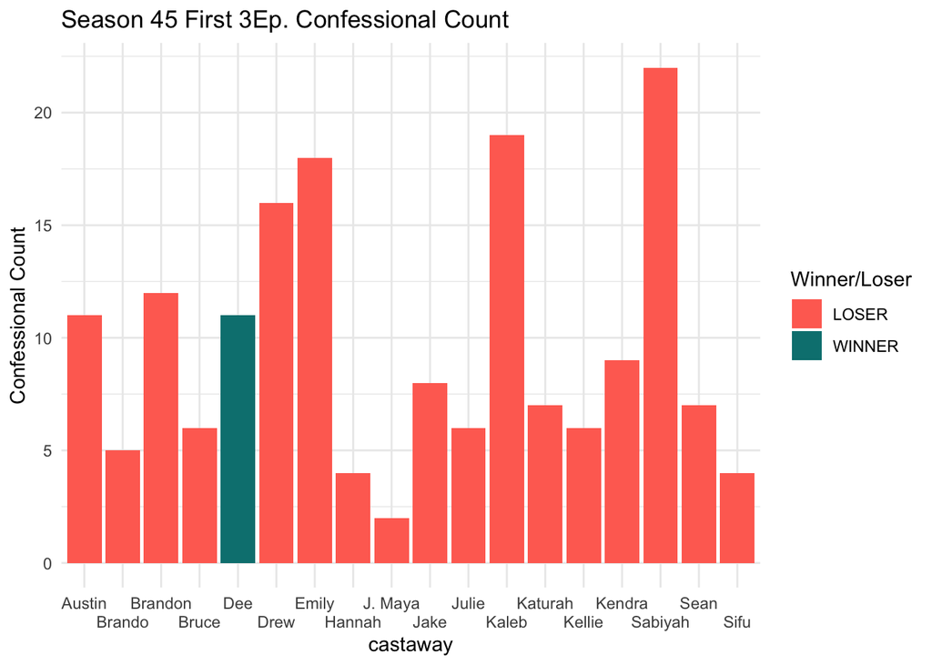

```r
season_45 <- castaway_df[castaway_df$season == '45', ]
ggplot(season_45,aes(castaway, total_confessional, fill = winner)) +
  geom_col(position = position_dodge(width = 0.5)) +
  scale_fill_manual(values = c("WINNER" = "#008080", "LOSER" = "#FF6F61")) +
   labs(title = 'Season 45 First 3Ep. Confessional Count', fill = 'Winner/Loser',
       y = 'Confessional Count') +
  scale_x_discrete(guide = guide_axis(n.dodge=2)) +
  theme_minimal()
```

```r
mean(season_45$total_confessional)
```

```
[1] 9.611111
```

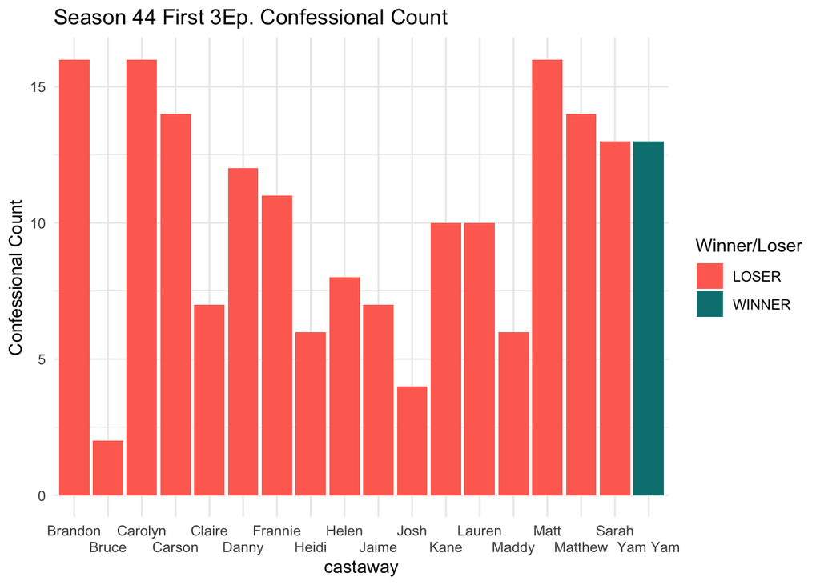

```r
season_44 <- castaway_df[castaway_df$season == '44', ]
ggplot(season_44,aes(castaway, total_confessional, fill = winner)) +
  geom_col(position = position_dodge(width = 0.5)) +
  scale_fill_manual(values = c("WINNER" = "#008080", "LOSER" = "#FF6F61")) +
   labs(title = 'Season 44 First 3Ep. Confessional Count', fill = 'Winner/Loser',
       y = 'Confessional Count') +
  scale_x_discrete(guide = guide_axis(n.dodge=2)) +
  theme_minimal()
```

```r
mean(season_44$total_confessional)
```

```
[1] 10.27778
```